# Mitigating the Impact of Covid on Forecasting Models

**Joaquin Amat Rodrigo, Javier Escobar Ortiz**

*December, 2022 (last update November 2024)*

**More about forecasting**

- [ARIMA and SARIMAX models with python](https://cienciadedatos.net/documentos/py51-arima-sarimax-models-python.html)
- [Time series forecasting with machine learning](https://cienciadedatos.net/documentos/py27-time-series-forecasting-python-scikitlearn.html)
- [Forecasting time series with gradient boosting: XGBoost, LightGBM and CatBoost](https://www.cienciadedatos.net/documentos/py39-forecasting-time-series-with-skforecast-xgboost-lightgbm-catboost.html)
- [Forecasting time series with XGBoost](https://cienciadedatos.net/documentos/py56-forecasting-time-series-with-xgboost.html)
- [Global Forecasting Models: Multi-series forecasting](https://www.cienciadedatos.net/documentos/py44-multi-series-forecasting-skforecast.html)
- [Global Forecasting Models: Comparative Analysis of Single and Multi-Series Forecasting Modeling](https://cienciadedatos.net/documentos/py53-global-forecasting-models.html)
- [Probabilistic forecasting](https://www.cienciadedatos.net/documentos/py42-probabilistic-forecasting.html)
- [Forecasting with deep learning](https://www.cienciadedatos.net/documentos/py54-forecasting-with-deep-learning.html)
- [Forecasting energy demand with machine learning](https://www.cienciadedatos.net/documentos/py29-forecasting-electricity-power-demand-python.html)
- [Forecasting web traffic with machine learning](https://www.cienciadedatos.net/documentos/py37-forecasting-web-traffic-machine-learning.html)
- [Intermittent demand forecasting](https://www.cienciadedatos.net/documentos/py48-intermittent-demand-forecasting)
- [Modelling time series trend with tree-based models](https://www.cienciadedatos.net/documentos/py49-modelling-time-series-trend-with-tree-based-models.html)
- [Bitcoin price prediction with Python](https://www.cienciadedatos.net/documentos/py41-forecasting-cryptocurrency-bitcoin-machine-learning-python.html)
- [Stacking ensemble of machine learning models to improve forecasting](https://cienciadedatos.net/documentos/py52-stacking-ensemble-models-forecasting.html)
- [Interpretable forecasting models](https://cienciadedatos.net/documentos/py57-interpretable-forecasting-models.html)
- [Mitigating the Impact of Covid on forecasting Models](https://cienciadedatos.net/documentos/py45-weighted-time-series-forecasting.html)
- [Forecasting time series with missing values](https://cienciadedatos.net/documentos/py46-forecasting-time-series-missing-values.html)

[figure not shown]

## Introduction

Although historical data is available in many real use cases of forecasting, not all are reliable. Some examples of these scenarios are:

- IoT sensors: within the Internet of Things, sensors capture the raw data from the physical world. Often the sensors are deployed or installed in harsh environments. This inevitably means that the sensors are prone to failure, malfunction, and rapid attrition, causing the sensor to produce unusual and erroneous readings.
- Factory shutdown: every certain period of operation, factories need to be shut down for repair, overhaul, or maintenance activities. These events cause production to stop, generating a gap in the data.
- Pandemic (Covid-19): the Covid 19 pandemic changed population behavior significantly, directly impacting many time series such as production, sales, and transportation.

The presence of unreliable or unrepresentative values in the data history is a major problem, as it hinders model learning. For most forecasting algorithms, removing that part of the data is not an option because they require the time series to be complete. An alternative solution is to reduce the weight of the affected observations during model training. This document shows two examples of how **skforecast** makes it easy to apply this strategy.

**✎ Note**

In the following examples, a portion of the time series is excluded from model training by giving it a weight of zero. However, the use of weights is not limited to including or excluding observations, but to balancing the degree of influence of each observation in the forecasting model. For example, an observation with a weight of 10 has 10 times more impact on the model training than an observation with a weight of 1.

**⚠ Warning**

In most gradient boosting implementations (LightGBM, XGBoost, CatBoost), samples with zero weight are ignored when calculating the gradients and hessians. However, the values for those samples are still considered when building the feature histograms. Therefore, the resulting model may differ from the model trained without the zero-weighted samples. See more details in this [issue](https://github.com/microsoft/LightGBM/issues/5553).

## Libraries

```python
# Data processing
# ==============================================================================
import pandas as pd
import numpy as np
from skforecast.datasets import fetch_dataset

# Plots
# ==============================================================================
import matplotlib.pyplot as plt
from skforecast.plot import set_dark_theme

# Modelling and Forecasting
# ==============================================================================
import skforecast
import sklearn
from sklearn.linear_model import Ridge
from skforecast.recursive import ForecasterRecursive
from skforecast.model_selection import TimeSeriesFold
from skforecast.model_selection import backtesting_forecaster

# Configuration
# ==============================================================================
import warnings
warnings.filterwarnings('once')

color = '\033[1m\033[38;5;208m'
print(f"{color}Version skforecast: {skforecast.__version__}")
print(f"{color}Version scikit-learn: {sklearn.__version__}")
print(f"{color}Version pandas: {pd.__version__}")
print(f"{color}Version numpy: {np.__version__}")
```

```
Version skforecast: 0.14.0
Version scikit-learn: 1.5.1
Version pandas: 2.2.3
Version numpy: 2.0.2
```

## Covid-19 lockdown

During the lockdown period imposed as a consequence of the covid-19 pandemic, the behavior of the population was altered. An example of this can be seen in the use of the bicycle rental service in the city of Madrid (Spain).

### Data

```python
# Data download
# ==============================================================================
data = fetch_dataset('bicimad')
data.head()
```

```
bicimad
-------
This dataset contains the daily users of the bicycle rental service (BiciMad) in
the city of Madrid (Spain) from 2014-06-23 to 2022-09-30.
The original data was obtained from: Portal de datos abiertos del Ayuntamiento
de Madrid https://datos.madrid.es/portal/site/egob
Shape of the dataset: (3022, 1)
```

| date | users |
| --- | --- |
| 2014-06-23 | 99 |
| 2014-06-24 | 72 |
| 2014-06-25 | 119 |
| 2014-06-26 | 135 |
| 2014-06-27 | 149 |

```python
# Split data into train-val-test
# ==============================================================================
data = data.loc['2020-01-01': '2021-12-31']
end_train = '2021-06-01'
data_train = data.loc[: end_train, :]
data_test  = data.loc[end_train:, :]

print(f"Dates train : {data_train.index.min()} --- {data_train.index.max()}  (n={len(data_train)})")
print(f"Dates test  : {data_test.index.min()} --- {data_test.index.max()}  (n={len(data_test)})")
```

```
Dates train : 2020-01-01 00:00:00 --- 2021-06-01 00:00:00  (n=518)
Dates test  : 2021-06-01 00:00:00 --- 2021-12-31 00:00:00  (n=214)
```

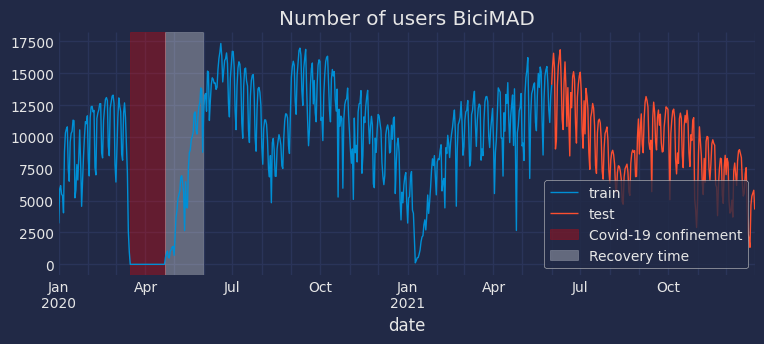

```python
# Time series plot
# ==============================================================================
set_dark_theme()
fig, ax = plt.subplots(figsize=(8, 3))
data_train.users.plot(ax=ax, label='train', linewidth=1)
data_test.users.plot(ax=ax, label='test', linewidth=1)
ax.axvspan(
    pd.to_datetime('2020-03-16'),
    pd.to_datetime('2020-04-21'),
    label="Covid-19 confinement",
    color="red",
    alpha=0.3
)

ax.axvspan(
    pd.to_datetime('2020-04-21'),
    pd.to_datetime('2020-05-31'),
    label="Recovery time",
    color="white",
    alpha=0.3
)

ax.set_title('Number of users BiciMAD')
ax.legend();
```

### Include the whole time series

A forecaster is initialized without taking into consideration the lockdown period.

```python
# Create recursive multi-step forecaster (ForecasterRecursive)
# ==============================================================================
forecaster = ForecasterRecursive(
                 regressor = Ridge(),
                 lags      = 21,
             )
forecaster
```

ForecasterRecursive

**General Information**

- **Regressor:** Ridge()

- **Lags:** [ 1 2 3 4 5 6 7 8 9 10 11 12 13 14 15 16 17 18 19 20 21]

- **Window features:** None

- **Window size:** 21

- **Exogenous included:** False

- **Weight function included:** False

- **Differentiation order:** None

- **Creation date:** 2024-11-04 15:58:24

- **Last fit date:** None

- **Skforecast version:** 0.14.0

- **Python version:** 3.12.5

- **Forecaster id:** None

**Exogenous Variables**

None

**Data Transformations**

- **Transformer for y:** None

- **Transformer for exog:** None

**Training Information**

- **Training range:** Not fitted

- **Training index type:** Not fitted

- **Training index frequency:** Not fitted

**Regressor Parameters**

{'alpha': 1.0, 'copy_X': True, 'fit_intercept': True, 'max_iter': None, 'positive': False, 'random_state': None, 'solver': 'auto', 'tol': 0.0001}

**Fit Kwargs**

{}

[🛈 **API Reference**](https://skforecast.org/0.14.0/api/forecasterrecursive.html) [🗎 **User Guide**](https://skforecast.org/0.14.0/user_guides/autoregresive-forecaster.html)

```python
# Backtesting: predict next 7 days at a time.
# ==============================================================================
cv = TimeSeriesFold(
        steps              = 7,
        initial_train_size = len(data.loc[:end_train]),
        fixed_train_size   = False,
        refit              = False,
)
metric, predictions_backtest = backtesting_forecaster(
                                   forecaster = forecaster,
                                   y          = data.users,
                                   cv         = cv,
                                   metric     = 'mean_absolute_error',
                                   verbose    = False
                               )
metric
```

|  | mean_absolute_error |
| --- | --- |
| 0 | 1469.144278 |

### Exclude part of the time series

To minimize the influence on the model of these dates, a custom function is created weights following the rules:

- Weight of 0 if index date is:
  - Within the lockdown period (2020-03-16 to 2020-04-21).
  - Within the recovery period (2020-04-21 to 2020-05-31).
  - 21 days after the recovery period to avoid including impacted values as lags (2020-05-31) to 2020-06-21).
- Weight of 1 otherwise.

If an observation has a weight of 0, it has no influence during model training.

```python
# Custom function to create weights
# ==============================================================================
def custom_weights(index):
    """
    Return 0 if index is one between 2020-03-16 and 2020-06-21.
    """
    weights = np.where((index >= '2020-03-16') & (index <= '2020-06-21'), 0, 1)

    return weights
```

Again, a `ForecasterAutoreg` is initialized but this time including the `custom_weights` function.

```python
# Create recursive multi-step forecaster (ForecasterAutoreg)
# ==============================================================================
forecaster = ForecasterRecursive(
                 regressor   = Ridge(random_state=123),
                 lags        = 21,
                 weight_func = custom_weights
             )

# Backtesting: predict next 7 days at a time.
# ==============================================================================
metric, predictions_backtest = backtesting_forecaster(
                                   forecaster = forecaster,
                                   y          = data.users,
                                   cv         = cv,
                                   metric     = 'mean_absolute_error',
                                   verbose    = False
                               )

metric
```

|  | mean_absolute_error |
| --- | --- |
| 0 | 1404.679364 |

Giving a weight of 0 to the lockdown period (excluding it from the model training) slightly improves the forecasting performance.

## Power plant shutdown

Power plants used to generate energy are very complex installations that require a high level of maintenance. It is common that, every certain period of operation, the plant has to be shut down for repair, overhaul, or maintenance activities.

### Data

```python
# Data download
# ==============================================================================
url = ('https://raw.githubusercontent.com/JoaquinAmatRodrigo/skforecast/master/'
       'data/energy_production_shutdown.csv')
data = pd.read_csv(url, sep=',')

# Data preprocessing
# ==============================================================================
data['date'] = pd.to_datetime(data['date'], format='%Y-%m-%d')
data = data.set_index('date')
data = data.asfreq('D')
data = data.sort_index()
data.head()
```

| date | production |
| --- | --- |
| 2012-01-01 | 375.1 |
| 2012-01-02 | 474.5 |
| 2012-01-03 | 573.9 |
| 2012-01-04 | 539.5 |
| 2012-01-05 | 445.4 |

```python
# Split data into train-test
# ==============================================================================
data = data.loc['2012-01-01 00:00:00': '2014-12-30 23:00:00']
end_train = '2013-12-31 23:59:00'
data_train = data.loc[: end_train, :]
data_test  = data.loc[end_train:, :]

print(f"Dates train : {data_train.index.min()} --- {data_train.index.max()}  (n={len(data_train)})")
print(f"Dates test  : {data_test.index.min()} --- {data_test.index.max()}  (n={len(data_test)})")
```

```
Dates train : 2012-01-01 00:00:00 --- 2013-12-31 00:00:00  (n=731)
Dates test  : 2014-01-01 00:00:00 --- 2014-12-30 00:00:00  (n=364)
```

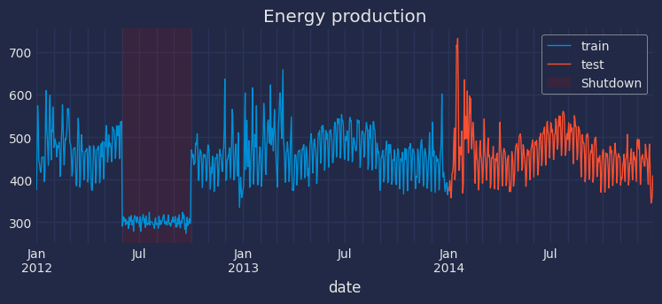

```python
# Time series plot
# ==============================================================================
fig, ax = plt.subplots(figsize=(8, 3))
data_train.production.plot(ax=ax, label='train', linewidth=1)
data_test.production.plot(ax=ax, label='test', linewidth=1)
ax.axvspan(
    pd.to_datetime('2012-06-01'),
    pd.to_datetime('2012-09-30'),
    label="Shutdown",
    color="red",
    alpha=0.1
)
ax.set_title('Energy production')
ax.legend();
```

### Include the whole time series

A forecaster is initialized without taking in consideration the shutdown period.

```python
# Create recursive multi-step forecaster (ForecasterAutoreg)
# ==============================================================================
forecaster = ForecasterRecursive(
                 regressor = Ridge(random_state=123),
                 lags      = 21,
             )
```

```python
# Backtesting: predict next 10 days at a time.
# ==============================================================================
cv = TimeSeriesFold(
        steps              = 10,
        initial_train_size = len(data.loc[:end_train]),
        refit              = False,
)
metric, predictions_backtest = backtesting_forecaster(
                                   forecaster = forecaster,
                                   y          = data.production,
                                   cv         = cv,
                                   metric     = 'mean_absolute_error',
                                   verbose    = False
                              )
metric
```

|  | mean_absolute_error |
| --- | --- |
| 0 | 28.424722 |

### Exclude part of the time series

The factory shutdown took place from 2012-06-01 to 2012-09-30. To minimize the influence on the model of these dates, a custom function is created that gives a value of 0 if the index date is within the shutdown period or 21 days later (lags used by the model) and 1 otherwise. If an observation has a weight of 0, it has no influence at all during model training.

```python
# Custom function to create weights
# ==============================================================================
def custom_weights(index):
    """
    Return 0 if index is one between 2012-06-01 and 2012-10-21.
    """
    weights = np.where((index >= '2012-06-01') & (index <= '2012-10-21'), 0, 1)
    return weights
```

```python
# Create recursive multi-step forecaster (ForecasterAutoreg)
# ==============================================================================
forecaster = ForecasterRecursive(
                 regressor   = Ridge(random_state=123),
                 lags        = 21,
                 weight_func = custom_weights
             )

# Backtesting: predict next 10 days at a time.
# ==============================================================================
metric, predictions_backtest = backtesting_forecaster(
                                   forecaster = forecaster,
                                   y          = data.production,
                                   cv         = cv,
                                   metric     = 'mean_absolute_error',
                                   verbose    = False
                               )
metric
```

|  | mean_absolute_error |
| --- | --- |
| 0 | 27.808331 |

As in the previous example, excluding the observations during the shutdown period slightly improves the forecasting performance.

## Session information

```python
import session_info
session_info.show(html=False)
```

```
-----
matplotlib          3.9.2
numpy               2.0.2
pandas              2.2.3
session_info        1.0.0
skforecast          0.14.0
sklearn             1.5.1
-----
IPython             8.27.0
jupyter_client      8.6.3
jupyter_core        5.7.2
notebook            6.4.12
-----
Python 3.12.5 | packaged by Anaconda, Inc. | (main, Sep 12 2024, 18:27:27) [GCC 11.2.0]
Linux-5.15.0-1071-aws-x86_64-with-glibc2.31
-----
Session information updated at 2024-11-04 15:58
```

## Citation

**How to cite this document**

If you use this document or any part of it, please acknowledge the source, thank you!

Mitigating the Impact of Covid on Forecasting Models by Joaquín Amat Rodrigo and Javier Escobar Ortiz, available under Attribution-NonCommercial-ShareAlike 4.0 International (CC BY-NC-SA 4.0 DEED) at https://www.cienciadedatos.net/documentos/py45-weighted-time-series-forecasting.html

**How to cite skforecast**

If you use skforecast for a publication, we would appreciate it if you cite the published software.

Zenodo:

Amat Rodrigo, Joaquin, & Escobar Ortiz, Javier. (2024). skforecast (v0.14.0). Zenodo. https://doi.org/10.5281/zenodo.8382788

APA:

Amat Rodrigo, J., & Escobar Ortiz, J. (2024). skforecast (Version 0.14.0) [Computer software]. https://doi.org/10.5281/zenodo.8382788

BibTeX:

@software{skforecast, author = {Amat Rodrigo, Joaquin and Escobar Ortiz, Javier}, title = {skforecast}, version = {0.14.0}, month = {11}, year = {2024}, license = {BSD-3-Clause}, url = {https://skforecast.org/}, doi = {10.5281/zenodo.8382788} }

This work by Joaquín Amat Rodrigo is licensed under a [Attribution-NonCommercial-ShareAlike 4.0 International](https://creativecommons.org/licenses/by-nc-sa/4.0/).